# Getting Started

## Dependencies

I assume that the notebook is running on a conda environment. The essential packages are

1. `numpy`
2. `scipy`
3. `mkl`
4. `cython`
5. `pandas`
6. `matplotlib`

These can be installed using the following command:

`conda install -c conda-forge numpy scipy mkl cython pandas`

## Folder structure

```
project
│   notebook.ipynb
│
└─── data
│   │   matrix.npz
│   │   genes.tsv
│   │   cells.tsv
│
└─── fastrna
     │   utils.so
     │   mkl_funcs.so
     │   core.so
```

### The program

The essential programs are pre-compiled and are provided by `*.so` files:

1. `fastrna/utils.so`
2. `fastrna/mkl_funcs.so`
3. `fastrna/core.so`

The libraries can be loaded as if they are the usual `*.py` files .e.g

`import fastrna.utils`

### The data

Three data where each contains the data matrix, gene annotations and cell annotations are attached.

The gene annotations contain the name of the genes. The gene name has two forms, one which is the `ensembl name` and the common name. The `ensembl name` is a collection of codes that specifies the gene in the form of `EN` + `Species code` + `Unique code`. The common name is the usual gene name abbreviation, e.g. `FTO` (Fat mass and obesity-associated protein).

The cell annotations contain the barcode and the batch membership of cells. The barcode are specifiers produced by scRNA-seq machines.

# Load basic libraries

```python
# These are the basic libraries to manipulate dataframes and arrays
import numpy as np

import scipy
import scipy.sparse as sparse

import pandas as pd

import matplotlib.pyplot as plt
import seaborn as sns
```

## Load data

```python
mtx = sparse.load_npz('data/matrix.npz')
cells = pd.read_csv('data/cells.tsv', sep='\t', index_col=0)
genes = pd.read_csv('data/genes.tsv', sep='\t', index_col=0)
```

`mtx` is the matrix storing transcript counts. Total 26183 genes and 46899 cells are inside the data.

```python
mtx
```

```
<26183x46899 sparse matrix of type '<class 'numpy.float32'>'
	with 32352958 stored elements in Compressed Sparse Column format>
```

`cells` contains the information of the cells. The index (named sample) is the barcodes of cells. `batch_label` column contains the donor membership of the cells.

```python
cells.head()
```

| sample | batch_label |
| --- | --- |
| sci3-me-689.GTAAGCTCTGCGTTGGAGC | 0 |
| sci3-me-239.TGCTGGATTAGAGCTATAA | 0 |
| sci3-me-325.AGGCATCATGCGTTGGAGC | 0 |
| sci3-me-731.TCATTAAGCTGCGTTGGAGC | 0 |
| sci3-me-080.TGCCTTGGTGCGTTGGAGC | 0 |

`genes` cotains the information of the genes. `common_name` is the common names of the genes. `ensembl` is the ensembl code for the genes.

```python
genes.head()
```

| gene_id | common_name | ensembl_name |
| --- | --- | --- |
| ENSMUSG00000051951.5 | Xkr4 | ENSMUSG00000051951.5 |
| ENSMUSG00000103377.1 | Gm37180 | ENSMUSG00000103377.1 |
| ENSMUSG00000104017.1 | Gm37363 | ENSMUSG00000104017.1 |
| ENSMUSG00000103025.1 | Gm37686 | ENSMUSG00000103025.1 |
| ENSMUSG00000089699.1 | Gm1992 | ENSMUSG00000089699.1 |

```python
genes.common_name
```

```
gene_id
ENSMUSG00000051951.5       Xkr4
ENSMUSG00000103377.1    Gm37180
ENSMUSG00000104017.1    Gm37363
ENSMUSG00000103025.1    Gm37686
ENSMUSG00000089699.1     Gm1992
                         ...
ENSMUSG00000064368.1     mt-Nd6
ENSMUSG00000064369.1      mt-Te
ENSMUSG00000064370.1    mt-Cytb
ENSMUSG00000064371.1      mt-Tt
ENSMUSG00000064372.1      mt-Tp
Name: common_name, Length: 26183, dtype: object
```

# Calculate and visualize QC metrics

Three quality control (QC) metrics are employed.

1. Total number of UMI counts in the data: the sum of all molecule counts in the data (summation over column)
2. Number of genes expressed in a cell: the number of non-zero genes for each cell
3. Mitochondrial gene content: number of mitochondrial gene transcripts divided by the number in 1.

```python
# metric 1
qc1 = np.asarray(mtx.sum(axis=0)).ravel()

# metric 2
qc2 = np.asarray((mtx > 0).sum(axis=0)).ravel()

# metric 3
mt_gene = genes.common_name.apply(lambda x: True if 'mt-' in x else False)
qc3 = np.asarray(mtx[mt_gene,:].sum(axis=0) / qc1 * 100).ravel()
```

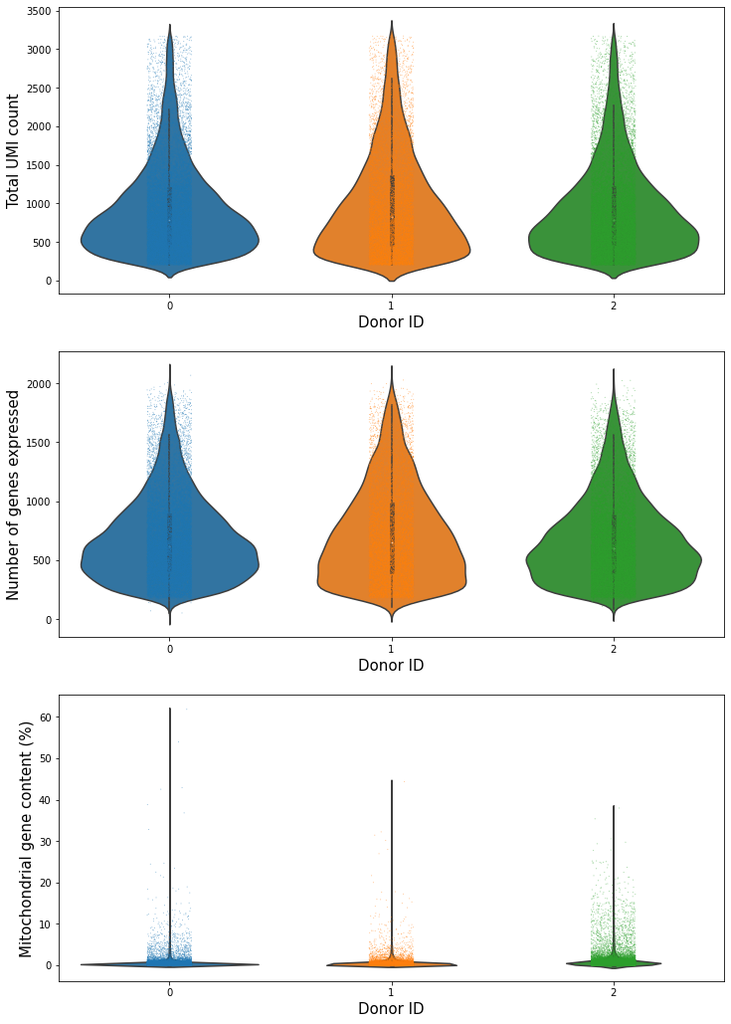

```python
fig, ax = plt.subplots(3, 1, figsize=(12, 18))

sns.violinplot(x=cells.batch_label, y=qc1, ax=ax[0])
sns.stripplot(x=cells.batch_label, y=qc1, ax=ax[0], s=1, alpha=0.5, edgecolor=None)
ax[0].set_ylabel('Total UMI count', fontsize=15)
ax[0].set_xlabel('Donor ID', fontsize=15)


sns.violinplot(x=cells.batch_label, y=qc2, ax=ax[1])
sns.stripplot(x=cells.batch_label, y=qc2, ax=ax[1], s=1, alpha=0.5, edgecolor=None)
ax[1].set_ylabel('Number of genes expressed', fontsize=15)
ax[1].set_xlabel('Donor ID', fontsize=15)

sns.violinplot(x=cells.batch_label, y=qc3, ax=ax[2])
sns.stripplot(x=cells.batch_label, y=qc3, ax=ax[2], s=1, alpha=0.5, edgecolor=None)
ax[2].set_ylabel('Mitochondrial gene content (%)', fontsize=15)
ax[2].set_xlabel('Donor ID', fontsize=15)

plt.show()
```

# Load FastRNA

`fastrna/utils.so` and `fastrna/mkl_funcs.so` contain internal functions to run the program. Therefore, the user should not require the commands inside these files.

```python
# Load fastrna/core.so
from fastrna.core import fastrna_hvg, fastrna_pca
```

`fastrna_hvg` performs feature selection. `hvg` is the abbreviation of 'highly variable genes'. The process ends within a second.

```python
%time gene_vars = fastrna_hvg(mtx, cells.batch_label.values)
gene_vars
```

```
CPU times: user 3.25 s, sys: 118 ms, total: 3.37 s
Wall time: 159 ms
```

```
array([1.8159729, 1.1183376, 0.9487971, ..., 1.382655 , 0.       ,
       0.6889128], dtype=float32)
```

```python
# order the gene index according to the variance in a descending order
gene_order_var = gene_vars.argsort()[::-1]
gene_order_var
```

```
array([23560, 12122, 17274, ...,  2434, 16164, 16965])
```

```python
mtx_hvg = mtx[gene_order_var[:2000],:] # select top 2000 genes
mtx_hvg.sort_indices() # order indices
numi = np.asarray(mtx.sum(axis=0)).ravel() # calculate the total transcript number of each cell
```

Now we run `fastrna_pca` which does the PCA.

```python
%time eig_val, eig_vec, pca, rrt = fastrna_pca(mtx_hvg, numi, cells.batch_label.values)
```

```
CPU times: user 10.6 s, sys: 872 ms, total: 11.5 s
Wall time: 436 ms
```

The outputs are

```python
# the eigenvalues
eig_val.shape, eig_val
```

```
((50,),
 array([6016043. , 4693921.5, 4563314. , 2603947. , 2393121. , 2317757.2,
        2270132.5, 2159225. , 2114888. , 2071872.4, 2019038.4, 2002399.4,
        1939960.1, 1866454.4, 1819417.4, 1810510.2, 1770791.4, 1766144.6,
        1732573.4, 1703794.9, 1694187.5, 1662639.6, 1646968. , 1642102.4,
        1602488.8, 1589575.4, 1572014.6, 1518915.9, 1483006.4, 1428431.4,
        1417525.1, 1378898.2, 1356417.4, 1349430.8, 1319037.4, 1300348.1,
        1299577.1, 1293267. , 1275102.6, 1257367. , 1253338.1, 1238474. ,
        1218722.1, 1213473. , 1207244.4, 1197908.9, 1180836.6, 1176932.4,
        1169922.2, 1167130.8], dtype=float32))
```

```python
# The eigenvectors
eig_vec.shape, eig_vec
```

```
((2000, 50),
 array([[ 8.5081765e-04, -2.1744813e-03,  2.3872009e-03, ...,
          1.9547180e-03,  4.2105353e-04,  1.7242008e-03],
        [ 1.1065070e-03, -2.9397964e-02,  3.4163173e-02, ...,
          4.5945081e-03,  4.6375522e-04, -3.0638555e-03],
        [ 7.0159009e-04, -3.7922174e-02,  4.2322263e-02, ...,
          4.0755426e-03, -2.5252246e-03, -2.1475523e-03],
        ...,
        [-1.0063872e-04,  2.1785051e-03, -2.2326410e-03, ...,
          2.0500068e-03,  1.7826101e-03, -1.0669599e-03],
        [-1.6440754e-05,  3.6641210e-04, -3.9490312e-04, ...,
          3.4950674e-05, -3.6800280e-05, -1.8233899e-04],
        [-5.2060121e-05, -1.4924431e-03,  1.8412345e-03, ...,
          1.3384799e-02,  5.1866155e-03, -1.1938163e-03]], dtype=float32))
```

```python
# The PCA coordinate
pca.shape, pca
```

```
((46899, 50),
 array([[-6.28763009e-05,  6.86945859e-04, -6.70827401e-04, ...,
          5.72456978e-04,  9.47583641e-04,  3.62708415e-05],
        [-3.94168201e-05,  3.53267562e-04, -2.96550861e-04, ...,
          1.07005041e-03,  1.00545073e-03,  2.80071661e-04],
        [-2.04769131e-05, -6.84715997e-05,  1.15189905e-04, ...,
          9.16087301e-04,  7.19151169e-04, -4.24124417e-04],
        ...,
        [-2.48096931e-05, -8.02975992e-05,  8.55460239e-05, ...,
         -3.41203995e-04,  2.69829208e-04, -7.87657860e-04],
        [-2.26751545e-05,  5.89573232e-04, -6.50534930e-04, ...,
         -1.34273650e-04, -9.63180268e-04, -6.47421228e-04],
        [-3.18622733e-05,  7.37517665e-04, -8.40514549e-04, ...,
          3.89427209e-04,  3.73608316e-04, -1.07912449e-04]], dtype=float32))
```

```python
# covariance matrix used for pca
rrt.shape, rrt
```

```
((2000, 2000),
 array([[ 7.3501406e+04,  3.0538379e+03,  2.2730962e+03, ...,
         -6.7342285e+02, -8.4871216e+01,  1.7154292e+03],
        [-3.9154418e+04,  1.3983141e+05,  1.9067361e+04, ...,
         -1.2724038e+03,  1.4244418e+03,  3.3400474e+03],
        [-3.5794898e+04, -1.9522969e+04,  1.4422475e+05, ...,
         -1.4051698e+03, -2.4536256e+02,  1.6175455e+03],
        ...,
        [-1.0314143e+04, -5.4388291e+03, -4.9774463e+03, ...,
          1.6798322e+05, -1.9054175e+02, -1.4843479e+03],
        [-1.3174738e+03, -6.7430884e+02, -6.1860474e+02, ...,
         -1.9054549e+02,  1.2295425e+05, -1.9995564e+02],
        [-1.1323316e+04, -6.0773320e+03, -5.5534072e+03, ...,
         -1.5820302e+03, -1.9994733e+02,  2.7649378e+05]], dtype=float32))
```

# PCA visualizatoin

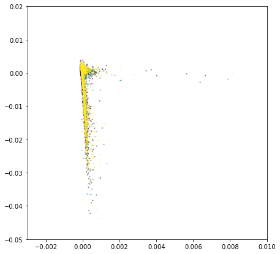

```python
fig, ax = plt.subplots(figsize=(7,7))
ax.scatter(pca[:,0], pca[:,1], s=1, c=cells.batch_label.values, alpha=0.5)
scale = 1e-2
ax.set_xlim([-scale*0.3, scale])
ax.set_ylim([-scale*5, scale*2])
plt.show()
```